# Case Study: How Does a Bike-Share Navigate Speedy Success?

This project is about a fictional bike sharing company, *Cyclistic*, that aim to maximize the number of annual membership. The idea is to analyse how casual riders and annual members use Cyclistic bikes differently and understand how they can have the casual riders to buy a membership.

Cyclistic has more than 5,800 bicycles and 600 docking stations. It sets itself apart by offering a very large selection of bikes, especially they look at people with disabilities and riders who can’t use a standard two-wheeled bike. Statistically speaking, 92% of Cyclistic users use standard bikes, moreover, only about the 30% of the total number of users use them to commute to work each day.

The company before this analysis has very flexible pricing plans: single-ride passes, full-day passes, and annual memberships. Customers who purchase single-ride or full-day passes are referred to as casual riders. Customers who purchase annual memberships are Cyclistic members.

Since the annual membership is the most profitable, the company’s director of marketing suggests that increasing the number of annual memberships is key to future growth.

The data used for the analysis are taken from [divvy-tripdata](https://divvy-tripdata.s3.amazonaws.com/index.html) opensource data. The use of these data is licensed under this [license](https://www.divvybikes.com/data-license-agreement).

## Data Preparation

Loading esseantial libraries:

```r
library("tidyverse")
```

```r
library("arsenal")
library("dplyr")
library("ggplot2")
```

To perform the required analysis I’m going to be using the data from the last 4 quarters; Q2, Q3 and Q4 of 2019 and Q1 of 2020.

```r
Q2_2019 <-
  read_csv('C:\\Users\\er_vi\\Documents\\GitHub\\Capstone_Bike-share\\Data\\Divvy_Trips_2019_Q2.csv',
           show_col_types = FALSE)
Q3_2019 <-
  read_csv('C:\\Users\\er_vi\\Documents\\GitHub\\Capstone_Bike-share\\Data\\Divvy_Trips_2019_Q3.csv',
           show_col_types = FALSE)
Q4_2019 <-
  read_csv('C:\\Users\\er_vi\\Documents\\GitHub\\Capstone_Bike-share\\Data\\Divvy_Trips_2019_Q4.csv',
           show_col_types = FALSE)
Q1_2020 <-
  read_csv('C:\\Users\\er_vi\\Documents\\GitHub\\Capstone_Bike-share\\Data\\Divvy_Trips_2020_Q1.csv',
           show_col_types = FALSE)
```

Let’s start to clean data. Since we have to work with four different files it is first important to have consistent column namings. We can check how are the columns named in each file running these commands

```r
colnames(Q2_2019)
```

```
##  [1] "01 - Rental Details Rental ID"
##  [2] "01 - Rental Details Local Start Time"
##  [3] "01 - Rental Details Local End Time"
##  [4] "01 - Rental Details Bike ID"
##  [5] "01 - Rental Details Duration In Seconds Uncapped"
##  [6] "03 - Rental Start Station ID"
##  [7] "03 - Rental Start Station Name"
##  [8] "02 - Rental End Station ID"
##  [9] "02 - Rental End Station Name"
## [10] "User Type"
## [11] "Member Gender"
## [12] "05 - Member Details Member Birthday Year"
```

```r
colnames(Q3_2019)
```

```
##  [1] "trip_id"           "start_time"        "end_time"
##  [4] "bikeid"            "tripduration"      "from_station_id"
##  [7] "from_station_name" "to_station_id"     "to_station_name"
## [10] "usertype"          "gender"            "birthyear"
```

```r
colnames(Q4_2019)
```

```
##  [1] "trip_id"           "start_time"        "end_time"
##  [4] "bikeid"            "tripduration"      "from_station_id"
##  [7] "from_station_name" "to_station_id"     "to_station_name"
## [10] "usertype"          "gender"            "birthyear"
```

```r
colnames(Q1_2020)
```

```
##  [1] "ride_id"            "rideable_type"      "started_at"
##  [4] "ended_at"           "start_station_name" "start_station_id"
##  [7] "end_station_name"   "end_station_id"     "start_lat"
## [10] "start_lng"          "end_lat"            "end_lng"
## [13] "member_casual"
```

These files do not have all the same column names but they share a total of nine columns, that are: **ride_id**, **rideable_type**, **started_at**, **ended_at**, **start_station_name**, **start_station_id**, **end_station_name**, **end_station_id** and **member_casual**, according to the namings used in the dataset Q1_2020.

In order to use these dataframes more easily in this step I create four new dataframes which contain only the columns they have in common,

```r
Q1_2020_clean <- Q1_2020[-c(9,10,11,12)]
Q4_2019_clean <- Q4_2019[-c(5,11,12)]
Q3_2019_clean <- Q3_2019[-c(5,11,12)]
Q2_2019_clean <- Q2_2019[-c(5,11,12)]
```

and I reorganize the columns in alphabetical order for a better comparison.

```r
Q1_2020_clean <- Q1_2020_clean %>% select(order(colnames(Q1_2020_clean)))
Q4_2019_clean <- Q4_2019_clean %>% select(order(colnames(Q4_2019_clean)))
Q3_2019_clean <- Q3_2019_clean %>% select(order(colnames(Q3_2019_clean)))
Q2_2019_clean <- Q2_2019_clean %>% select(order(colnames(Q2_2019_clean)))
```

Now we have to check that the attributes have consistent types. For this we can use the str() function from the dplyr package.

```r
str(Q1_2020_clean, give.attr = FALSE, give.length = FALSE, vec.len = 0)
```

```
## tibble [426,887 × 9] (S3: tbl_df/tbl/data.frame)
##  $ end_station_id    : num  NULL ...
##  $ end_station_name  : chr   ...
##  $ ended_at          : POSIXct, format:  ...
##  $ member_casual     : chr   ...
##  $ ride_id           : chr   ...
##  $ rideable_type     : chr   ...
##  $ start_station_id  : num  NULL ...
##  $ start_station_name: chr   ...
##  $ started_at        : POSIXct, format:  ...
```

```r
str(Q4_2019_clean, give.attr = FALSE, give.length = FALSE, vec.len = 0)
```

```
## tibble [704,054 × 9] (S3: tbl_df/tbl/data.frame)
##  $ end_station_id    : num  NULL ...
##  $ end_station_name  : chr   ...
##  $ ended_at          : POSIXct, format:  ...
##  $ member_casual     : chr   ...
##  $ ride_id           : num  NULL ...
##  $ rideable_type     : num  NULL ...
##  $ start_station_id  : num  NULL ...
##  $ start_station_name: chr   ...
##  $ started_at        : POSIXct, format:  ...
```

```r
str(Q3_2019_clean, give.attr = FALSE, give.length = FALSE, vec.len = 0)
```

```
## tibble [1,640,718 × 9] (S3: tbl_df/tbl/data.frame)
##  $ end_station_id    : num  NULL ...
##  $ end_station_name  : chr   ...
##  $ ended_at          : POSIXct, format:  ...
##  $ member_casual     : chr   ...
##  $ ride_id           : num  NULL ...
##  $ rideable_type     : num  NULL ...
##  $ start_station_id  : num  NULL ...
##  $ start_station_name: chr   ...
##  $ started_at        : POSIXct, format:  ...
```

```r
str(Q2_2019_clean, give.attr = FALSE, give.length = FALSE, vec.len = 0)
```

```
## tibble [1,108,163 × 9] (S3: tbl_df/tbl/data.frame)
##  $ end_station_id    : num  NULL ...
##  $ end_station_name  : chr   ...
##  $ ended_at          : POSIXct, format:  ...
##  $ member_casual     : chr   ...
##  $ ride_id           : num  NULL ...
##  $ rideable_type     : num  NULL ...
##  $ start_station_id  : num  NULL ...
##  $ start_station_name: chr   ...
##  $ started_at        : POSIXct, format:  ...
```

From the output is clear that the type of the columns **ride_id** and **rideable_type** from the *Q1_2020* is different from the other datasets. *Q1_2020* is char instead of numerical. Let’s convert these columns type into char.

```r
Q4_2019_clean <-  mutate(Q4_2019_clean, ride_id = as.character(ride_id)
                   ,rideable_type = as.character(rideable_type))
Q3_2019_clean <-  mutate(Q3_2019_clean, ride_id = as.character(ride_id)
                   ,rideable_type = as.character(rideable_type))
Q2_2019_clean <-  mutate(Q2_2019_clean, ride_id = as.character(ride_id)
                   ,rideable_type = as.character(rideable_type))
```

We are now ready to merge these four datasets into one.

```r
trips <- bind_rows(Q2_2019_clean, Q3_2019_clean, Q4_2019_clean, Q1_2020_clean)
```

## Data Cleaning

The next step is to clean our dataset **trips**. Let’s inspect the dataset. The first thing to check is if the column **member_casual** present any inconsistencies. Let’s check what values the attributes have,

```r
unique(trips["member_casual"])
```

```
## # A tibble: 4 × 1
##   member_casual
##   <chr>
## 1 Subscriber
## 2 Customer
## 3 member
## 4 casual
```

```r
trips <-  trips %>%
  mutate(member_casual = recode(member_casual
                           ,"Subscriber" = "member"
                           ,"Customer" = "casual"))
```

Next let’s add a new colum in order to have a better data aggregation such as splitting the date of a ride into *day-month-year*.

```r
trips$date <- as.Date(trips$started_at)
trips$month <- format(as.Date(trips$date), "%m")
trips$day <- format(as.Date(trips$date), "%d")
trips$year <- format(as.Date(trips$date), "%Y")
trips$day_of_week <- format(as.Date(trips$date), "%A")
```

Finally, let’s add other columns that indicates the duration of a trip. This can give insights on how customers with different memberships use the bike-sharing service.

```r
trips$ride_length <- difftime(trips$ended_at,trips$started_at) # Given in seconds
str(trips$ride_length) # Let's inspect the newly created attributes
```

```
##  'difftime' num [1:3879822] 446 1048 252 357 ...
##  - attr(*, "units")= chr "secs"
```

```r
trips$ride_length <- as.numeric(as.character(trips$ride_length)) # Convert to numeric
sum(trips$ride_length <= 0)
```

```
## [1] 223
```

Let’s check the other attributes for trips with a negative duration,

```r
head(filter(trips,ride_length<0))
```

```
## # A tibble: 6 × 15
##   end_stat…¹ end_s…² ended_at            membe…³ ride_id ridea…⁴ start…⁵ start…⁶
##        <dbl> <chr>   <dttm>              <chr>   <chr>   <chr>     <dbl> <chr>
## 1        133 Kingsb… 2019-11-03 01:09:56 casual  256258… 4141        632 Clark …
## 2        498 Califo… 2019-11-03 01:10:44 casual  256258… 6329        373 Kedzie…
## 3         87 Racine… 2019-11-03 01:02:40 member  256258… 964         229 Southp…
## 4        131 Lincol… 2019-11-03 01:16:48 member  256258… 2214        131 Lincol…
## 5        258 Logan … 2019-11-03 01:04:25 member  256258… 4179        298 Lincol…
## 6        238 Wolcot… 2019-11-03 01:03:02 member  256258… 2920        460 Clark …
## # … with 7 more variables: started_at <dttm>, date <date>, month <chr>,
## #   day <chr>, year <chr>, day_of_week <chr>, ride_length <dbl>, and
## #   abbreviated variable names ¹end_station_id, ²end_station_name,
## #   ³member_casual, ⁴rideable_type, ⁵start_station_id, ⁶start_station_name
```

```r
tail(filter(trips,ride_length<0))
```

```
## # A tibble: 6 × 15
##   end_stat…¹ end_s…² ended_at            membe…³ ride_id ridea…⁴ start…⁵ start…⁶
##        <dbl> <chr>   <dttm>              <chr>   <chr>   <chr>     <dbl> <chr>
## 1        675 HQ QR   2020-03-18 09:16:35 casual  CA4958… docked…     675 HQ QR
## 2        675 HQ QR   2020-03-18 15:12:04 casual  C2F71E… docked…     675 HQ QR
## 3        675 HQ QR   2020-03-13 08:38:03 casual  14AF58… docked…     675 HQ QR
## 4        675 HQ QR   2020-03-19 10:24:05 casual  D94EF1… docked…     675 HQ QR
## 5        675 HQ QR   2020-03-13 08:51:34 casual  323CAC… docked…     675 HQ QR
## 6        675 HQ QR   2020-03-19 09:31:45 casual  476717… docked…     675 HQ QR
## # … with 7 more variables: started_at <dttm>, date <date>, month <chr>,
## #   day <chr>, year <chr>, day_of_week <chr>, ride_length <dbl>, and
## #   abbreviated variable names ¹end_station_id, ²end_station_name,
## #   ³member_casual, ⁴rideable_type, ⁵start_station_id, ⁶start_station_name
```

Some of them have the **starting_station_name = HQ QR** that is the head quarter where a bike has been brought for being repaired. Since these attributes fo not correspond to any customer it is necessary to remove them as well. We can also check that there are other trips with a positive duration that started at the station **HQ QR**,

```r
sum(trips$start_station_name == "HQ QR") > sum(trips$ride_length <= 0)
```

```
## [1] TRUE
```

Let’s remove all the entries where **start_station_name** == “HQ QR” and **ride_length** <= 0.

```r
trips_clean <- trips[!(trips$start_station_name == "HQ QR" | trips$ride_length<0),]
sum(trips_clean$start_station_name == "HQ QR") # Check that the entries have been removed
```

```
## [1] 0
```

```r
sum(trips_clean$ride_length <= 0) # Check that the entries have been removed
```

```
## [1] 0
```

This step concludes the cleaning phase of the data analysis. Let’s move onto the analysis itself.

## Analysis

```r
trips_clean %>%
  aggregate(ride_length ~ member_casual, FUN = mean)
```

```
##   member_casual ride_length
## 1        casual   3552.7502
## 2        member    850.0662
```

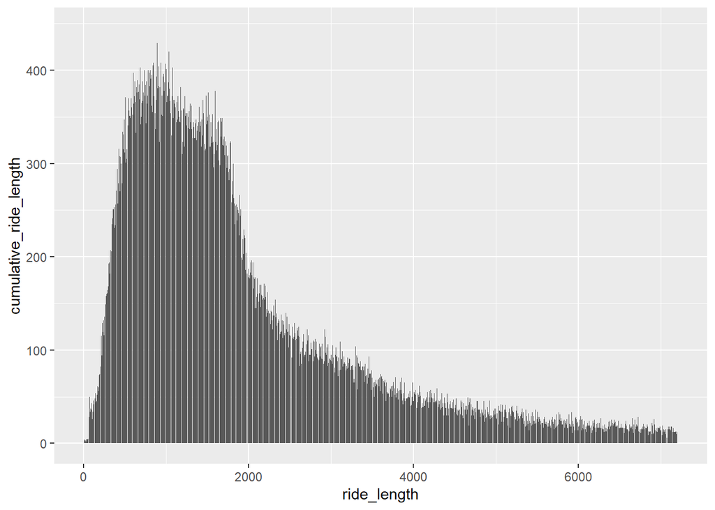

```r
trips_clean$cumulative_ride_length <- 1
trips_clean %>%
  filter(ride_length < 7200 & member_casual=="casual") %>%
  arrange(ride_length) %>%
    aggregate(cumulative_ride_length ~ ride_length, FUN = sum) %>%
  ggplot(aes(x = ride_length, y = cumulative_ride_length)) +
  geom_col(position = "dodge")
```